# Hessian

## SIR

```r
library(numDeriv)
library(bbmle)
library(fitsir)
## these aren't exported, probably should be
findSSQ <- fitsir:::findSSQ
findSens <- fitsir:::findSens
fitsir.optim <- fitsir:::fitsir.optim
library(deSolve)
library(emdbook)
## source("../R/fitSIR_funs.R")
library("devtools")
load_all("..")
bombay2 <- setNames(bombay, c("tvec", "count"))
fpars <- coef(f1 <- fitsir(bombay2, start = startfun()))

jacobian(fitsir:::findSSQ, fpars, data = bombay2, SSQonly = TRUE)
```

```
##         [,1]     [,2]     [,3]      [,4]
## [1,] -326677 273430.2 14450.28 -6796.896
```

```r
findSens(bombay2, fpars, sensOnly = TRUE)
```

```
##    SSQ_beta   SSQ_gamma       SSQ_N      SSQ_I0
## -326616.928  273372.086   14450.384   -6796.716
```

Jacobian seems to work fairly well. Can we find the Hessian?

```r
## fully finite-difference (Richardson)
(hess.m <- hessian(fitsir:::findSSQ, fpars, data = bombay2, SSQonly = TRUE))
```

```
##              [,1]         [,2]          [,3]         [,4]
## [1,]  46287880936 -45975012189  837885831.84  68435092.46
## [2,] -45975012189  45813513714 -778248039.74 -90717365.16
## [3,]    837885832   -778248040   10719973.87     35996.87
## [4,]     68435092    -90717365      35996.87   2118718.49
```

```r
## finite difference of symbolic gradient
(hess.grad <- jacobian(fitsir:::findSens, fpars, data = bombay2, sensOnly = TRUE))
```

```
##              [,1]         [,2]          [,3]          [,4]
## [1,]  79242505058 -77161188787  506892134.45  328981195.47
## [2,] -77161179425  75181978657 -512277591.79 -314818009.73
## [3,]    506890359   -512275883   10719968.68      36013.94
## [4,]    328983027   -314819835      36027.87    2118719.84
```

Here’s the model:

$\begin{aligned} &\frac{dSSQ}{d\log \theta}\\ &= \frac{dSSQ}{d\theta} \frac{d\theta}{d\log \theta}\\ &= \frac{dSSQ}{dI} \frac{dI}{d\theta} \frac{d\theta}{d\log\theta}\\ &= 2(I-\hat{I}) \frac{dI}{d\theta} \theta \end{aligned}$

Second derivative:

$\begin{aligned} &\frac{d(dSSQ/d\log\theta_1)}{d\log\theta_2}\\ &= \frac{d(dSSQ/d\log\theta_1)}{d\theta_2} \theta_2\\ &= (2\frac{dI}{d\theta_2} \frac{dI}{d\theta_1} \theta_1 + 2(I-\hat{I}) \frac{d^2I}{d\theta_1\theta_2}\theta_1 + 2(I-\hat{I})\frac{dI}{d\theta_1} \frac{d\theta_1}{d\theta_2} ) \theta_2\\ \end{aligned}$

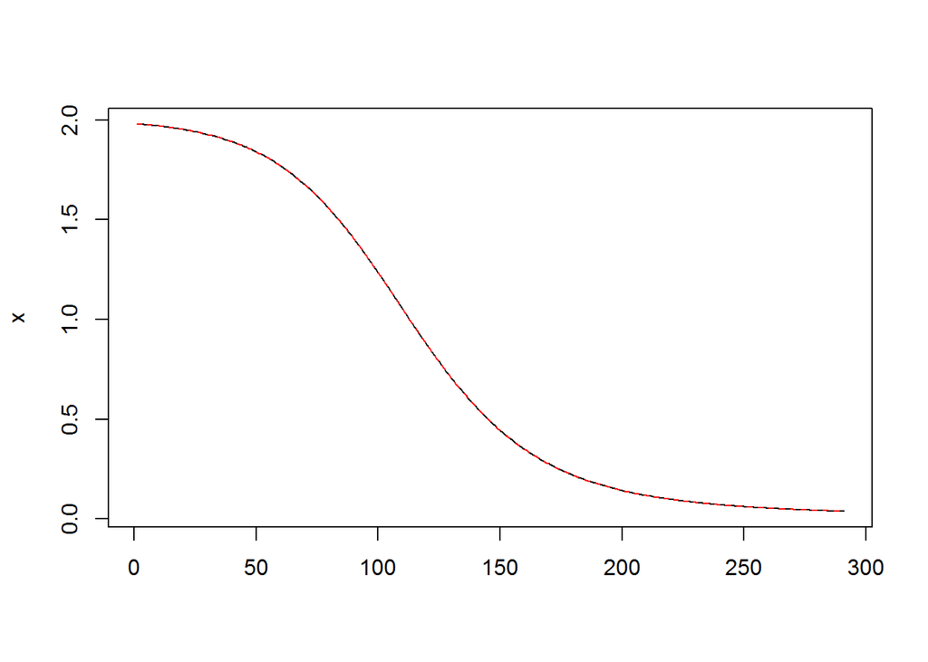

```r
tvec <- seq(1,30,0.1)

pars <- c(
    beta = 0.5,
    gamma = 0.1,
    N = 2,
    i0 = 0.01
)

pars2 <- c(
    beta = 0.5,
    gamma = 0.100001,
    N = 2,
    i0 = 0.01
)

r1 <- SIR.detsim.hessian(tvec, pars)

r2 <- SIR.detsim.hessian(tvec, pars2)

matplot(cbind(r1$S, r2$S), type = "l")
```

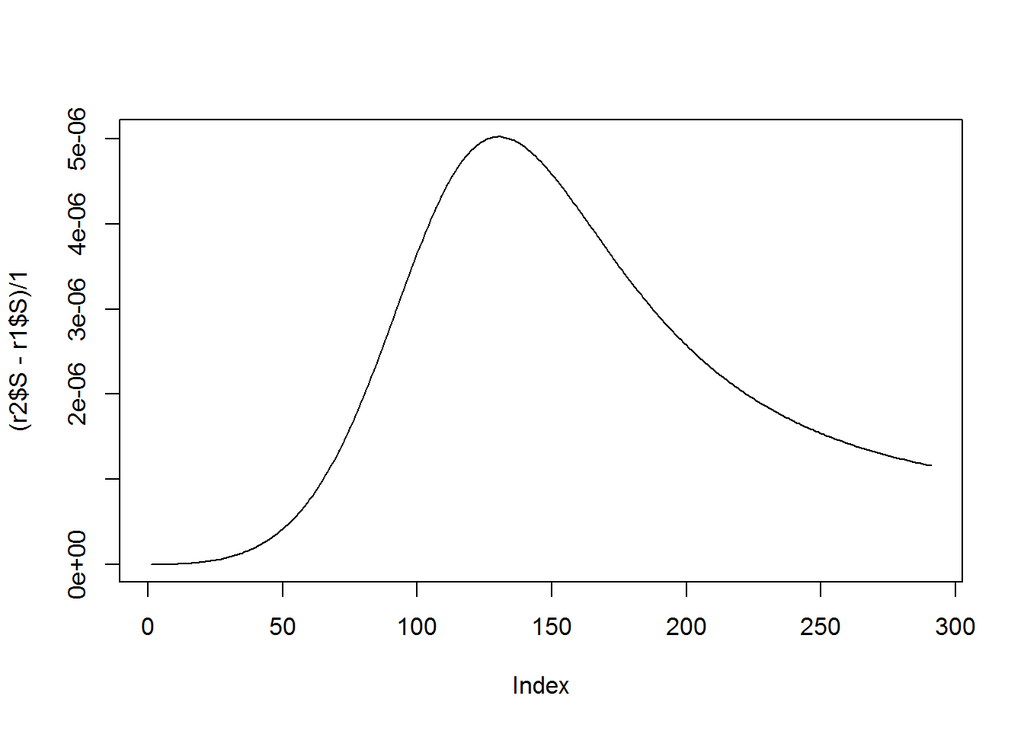

```r
plot((r2$S-r1$S)/1, type = "l")
lines(r1$nu_S_N, col = 2)
lines(r2$nu_S_N, col = 3)
```

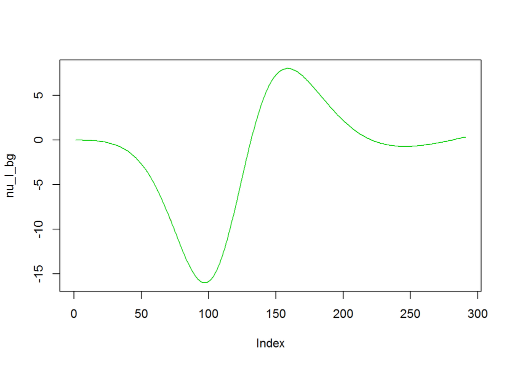

```r
nu_I_bg = (r2$nu_I_b-r1$nu_I_b)/0.000001

plot(nu_I_bg, type = "l")
lines(r1$nu_I_bg, col = 2)
lines(r2$nu_I_bg, col = 3)
```

True hessian function:

```r
(hess.alg <- findHess(bombay2, fpars))
```

```
##              [,1]         [,2]         [,3]         [,4]
## [1,]  79242462035 -77161139822  506890447.6  328982199.4
## [2,] -77161139822  75181933284 -512275953.1 -314818994.2
## [3,]    506890448   -512275953   10719959.7      36020.7
## [4,]    328982199   -314818994      36020.7    2118720.8
```

```r
(hess.grad <- jacobian(findSens, fpars, data = bombay2, sensOnly = TRUE))
```

```
##              [,1]         [,2]          [,3]          [,4]
## [1,]  79242505058 -77161188787  506892134.45  328981195.47
## [2,] -77161179425  75181978657 -512277591.79 -314818009.73
## [3,]    506890359   -512275883   10719968.68      36013.94
## [4,]    328983027   -314819835      36027.87    2118719.84
```

```r
all.equal(hess.alg, hess.grad)
```

```
## [1] "Mean relative difference: 5.899972e-07"
```

```r
eigen(hess.alg)
```

```
## $values
## [1] 1.544047e+11 3.227884e+07 2.055184e+05 1.118056e+03
##
## $vectors
##              [,1]       [,2]      [,3]       [,4]
## [1,]  0.716334760 -0.6072226 0.1415314 -0.3132317
## [2,] -0.697734933 -0.6208353 0.1526154 -0.3231687
## [3,]  0.004666866  0.4749109 0.6098983 -0.6343988
## [4,]  0.002948925 -0.1424915 0.7646577  0.6284792
```

I want to do this with negative log likelihood

```r
grad(SIR.logLik(), fpars, count = bombay2$count)
```

```
## [1] -56.137380  47.074128   2.448676  -1.161574
```

```r
findSens(bombay2, fpars, nll = TRUE, sensOnly = TRUE)
```

```
##    SSQ_beta   SSQ_gamma       SSQ_N      SSQ_I0
## -1.78080415  1.49049882  0.07878742 -0.03705754
```

These should be identical… I’m guessing that we’re not using the correct method for some reason…

$-l(x; \mu, \sigma^2) = \frac{1}{2} \log(\sigma^2) + \frac{(x-\mu)^2}{2\sigma^2} + C$

Substitute $x = I$, $\mu = \hat{I}$, and $\sigma^2 = \sum_i \frac{(I_i - \hat{I}_i)^2}{n-1}$, and perform chain rule:

$\begin{aligned} \frac{d(nll)}{d\theta} &= \sum_i \frac{d}{d\theta} (\frac{1}{2} \log(\sigma^2) + \frac{(x_i-\mu_i)^2}{2\sigma^2})\\ &= \sum_i (\frac{\mu_i-x_i}{\sigma^2} \frac{\partial \mu_i}{\partial \theta} + (\frac{1}{2\sigma^2} - \frac{(x_i-\mu_i)^2}{2 \sigma^4}) \frac{\partial \sigma^2}{\partial \theta})\\ &= \sum_i (\frac{\mu_i-x_i}{\sigma^2} \frac{\partial \hat{I}_i}{\partial \theta} + (\frac{1}{2\sigma^2} - \frac{(x_i-\mu_i)^2}{2 \sigma^4}) \sum_j \frac{\partial \sigma^2}{\partial \hat{I}_i} \frac{\partial \hat{I}_i}{\partial \theta})\\ \end{aligned}$

```r
nllSens <- function(data, params){
    t <- data$tvec
    tpars <- trans.pars(params)
    r <- SIR.detsim.hessian(t, tpars)

    with(as.list(c(r, tpars)),{

        n <- length(t)
        count <- data$count
        sigma2 <- sum((I-count)^2)/(n-1)

        sensVec <- c(beta, gamma, N, i0^2*exp(-qlogis(i0)))

        derVec <- c("nu_I_b", "nu_I_g", "nu_I_N", "nu_I_i")

        findDeriv <- function(i){
            d1 <- get(derVec[i])

            deriv <- sum((I-count)/sigma2 * d1 + (1/(2*sigma2) - ((I - count)^2)/(2*sigma2^2)) * sum(2 * (I - count)/(n-1) * d1)) * sensVec[i]
            return(deriv)
        }

        sens <- c(1:4)
        return(unlist(lapply(sens, findDeriv)))
    })
}
```

Does this work well?

```r
##They certainly look similar...
grad(SIR.logLik(), fpars, count = bombay2$count)
```

```
## [1] -56.137380  47.074128   2.448676  -1.161574
```

```r
nllSens(bombay2, fpars)
```

```
## [1] -55.261577  46.260901   2.441976  -1.148948
```

```r
##Can I take a look at the hessian matrix?
hessian(SIR.logLik(), fpars, count = bombay2$count)
```

```
##              [,1]         [,2]        [,3]       [,4]
## [1,]  206914.9376 -197572.8492 -2932.53725 -845.77691
## [2,] -197572.8492  211509.4861 -4181.21364 -936.76138
## [3,]   -2932.5372   -4181.2136  1234.27630  -83.60117
## [4,]    -845.7769    -936.7614   -83.60117  344.51634
```

```r
jacobian(nllSens, fpars, data = bombay2)
```

```
##              [,1]         [,2]         [,3]          [,4]
## [1,]  13393401.82 -13041647.84  85683.57233  55600.632536
## [2,] -13041647.84  12707148.26 -86592.41501 -53207.427997
## [3,]     85683.57    -86592.41   1811.50799      6.269249
## [4,]     55600.63    -53207.43      6.26925    358.022038
```

```r
fpars2 <- coef(f2 <- fitsir(bombay2, start = startfun(data = bombay2, auto = TRUE)))

##These look different now...
grad(SIR.logLik(), fpars2, count = bombay2$count)
```

```
## [1] -16.997663  16.850727  -2.139553  -2.328676
```

```r
nllSens(bombay2, fpars2)
```

```
## [1] -16.66075500  16.47157597   0.07089977   0.09965838
```

```r
fpars3 <- fpars2

fpars3[["log.N"]] <- fpars2[["log.N"]] + 1e-10

(SIR.logLik()(fpars3, bombay2$count)-SIR.logLik()(fpars2, bombay2$count))/1e-10
```

```
## [1] -1.799378
```

Can I find the hessian?

```r
nllHess <- function(data, params){
    t <- data$tvec
    tpars <- trans.pars(params)
    r <- SIR.detsim.hessian(t, tpars)

    with(as.list(c(r, tpars)),{

        n <- length(t)
        count <- data$count
        sigma2 <- sum((I-count)^2)/(n-1)

        sensVec <- c(beta, gamma, N, i0^2*exp(-qlogis(i0)))

        sensVec2 <- c(1, 1, 1, 2*i0*exp(-qlogis(i0)) - i0^2 * exp(-qlogis(i0)) * 1/(i0-i0^2))

        derVec <- c("nu_I_b", "nu_I_g", "nu_I_N", "nu_I_i")

        derMat <- matrix(c("nu_I_bb", "nu_I_bg", "nu_I_bN", "nu_I_bi",
                           "nu_I_bg", "nu_I_gg", "nu_I_gN", "nu_I_gi",
                           "nu_I_bN", "nu_I_gN", "nu_I_NN", "nu_I_Ni",
                           "nu_I_bi", "nu_I_gi", "nu_I_Ni", "nu_I_ii"), 4, 4)

        findDeriv <- function(i1, i2){
            d1 <- get(derVec[i1])
            d2 <- get(derVec[i2])

            db <- get(derMat[i1,i2])

            if(i1 == i2){
                d12 <- sensVec2[i1]
            }else{
                d12 <- 0
            }

            diff_I <- I - count

            dsigma_I <- 2 * diff_I/(n-1)

            dsigma_theta1 <- sum(dsigma_I * d1)
            dsigma_theta2 <- sum(dsigma_I * d2)

            deriv <- sum((1/sigma2 * d2 - diff_I/sigma2^2 * dsigma_theta2) * d1 +
                diff_I/sigma2 * db +
                (-1/(2*sigma2^2) * dsigma_theta2 + (diff_I)^2/sigma2^3 * dsigma_theta2 - diff_I/(sigma2^2) * d2) * dsigma_theta1 +
                (1/(2*sigma2^2) - diff_I^2/(2*sigma2^2)) * sum(2 * (d2 * d1 + diff_I * db))) * sensVec[i1] * sensVec[i2] +
                sum(diff_I/sigma2 * d1 +
                        (1/(2*sigma2) - (diff_I^2)/(2*sigma2^2)) * dsigma_theta1) * d12 * sensVec[i2]

            return(deriv)
        }
        m <- matrix(NA, 4, 4)

        for(i in 1:4){
            for(j in 1:4){
                m[i,j] = findDeriv(i,j)
            }
        }

        return(m)
    })
}
```

Test:

```r
jacobian(nllSens, fpars, data = bombay2)
```

```
##              [,1]         [,2]         [,3]          [,4]
## [1,]  13393401.82 -13041647.84  85683.57233  55600.632536
## [2,] -13041647.84  12707148.26 -86592.41501 -53207.427997
## [3,]     85683.57    -86592.41   1811.50799      6.269249
## [4,]     55600.63    -53207.43      6.26925    358.022038
```

```r
nllHess(bombay2, fpars)
```

```
##            [,1]       [,2]          [,3]          [,4]
## [1,] -375755227  365884336 -2403574.1277 -1559978.1912
## [2,]  365884336 -356497925  2429112.6388  1492818.1663
## [3,]   -2403574    2429113   -50761.5441     -170.6226
## [4,]   -1559978    1492818     -170.6226   -10080.0582
```

```r
hessian(SIR.logLik(), fpars2, count = bombay2$count)
```

```
##              [,1]         [,2]      [,3]      [,4]
## [1,]  128834.0246 -120782.8221 -2127.391 -681.6885
## [2,] -120782.8221  129960.8246 -2952.685 -690.4969
## [3,]   -2127.3913   -2952.6847  1111.549  -96.6230
## [4,]    -681.6885    -690.4969   -96.623  344.6513
```

```r
jacobian(nllSens, fpars2, data = bombay2)
```

```
##              [,1]         [,2]          [,3]          [,4]
## [1,]  137775703.2 -136652523.7  2.812065e+05  1.794054e+05
## [2,] -136652361.8  135546652.3 -2.821172e+05 -1.769629e+05
## [3,]     281202.0    -282113.0  1.827696e+03  7.839773e+00
## [4,]     179402.5    -176960.1  7.839772e+00  3.684964e+02
```